# R Notebook

# Partie 1: Stats unidimensionnelle

Exo1:

```r
library(BioStatR)
str(Mesures)
```

```
'data.frame':   252 obs. of  3 variables:
 $ masse : num  28.6 20.6 29.2 32 24.5 29 28.9 18.2 7.9 15.5 ...
 $ taille: num  19.1 14.8 19.7 21.1 19.4 19.5 18.9 14.6 10.2 14.6 ...
 $ espece: Factor w/ 4 levels "bignone","glycine blanche",..: 2 2 2 2 2 2 2 2 2 2 ...
```

```r
names(Mesures)
```

```
[1] "masse"  "taille" "espece"
```

1.nombre d’enregistremnts

```r
dim(Mesures)[1]
```

```
[1] 252
```

2.Nombre de variable

```r
dim(Mesures[2])
```

```
[1] 252   1
```

3. Comment afficher les 15 derniers enregistrements du DataSet ?

```r
tail(Mesures,15)
```

|  | masse | taille | espece |
| --- | --- | --- | --- |
| 238 | 3.8 | 14.4 | laurier rose |
| 239 | 5.3 | 13.4 | laurier rose |
| 240 | 5.8 | 14.7 | laurier rose |
| 241 | 4.6 | 14.9 | laurier rose |
| 242 | 3.2 | 10.5 | laurier rose |
| 243 | 4.3 | 14.6 | laurier rose |
| 244 | 2.7 | 11.3 | laurier rose |
| 245 | 2.6 | 9.1 | laurier rose |
| 246 | 2.4 | 9.0 | laurier rose |
| 247 | 2.6 | 9.4 | laurier rose |

[output cut: 5 more lines]

Exo2: Modalités de la variable espece:

```r
mes_especes<-Mesures$espece
modalites<-levels(mes_especes)
modalites
```

```
[1] "bignone"          "glycine blanche"  "glycine violette" "laurier rose"
```

```r
modalites[2]
```

```
[1] "glycine blanche"
```

1. Quels sont les effectifs de chaque modalité du caractère espece ?

```r
length(mes_especes[mes_especes=="bignone"])
```

```
[1] 70
```

```r
length(mes_especes[mes_especes=="glycine blanche"])
```

```
[1] 54
```

```r
length(mes_especes[mes_especes=="glycine violette"])
```

```
[1] 56
```

```r
length(mes_especes[mes_especes=="laurier rose"])
```

```
[1] 72
```

```r
length(which(mes_especes=="bignone"))
```

```
[1] 70
```

```r
table(mes_especes)
```

```
mes_especes
         bignone  glycine blanche glycine violette     laurier rose
              70               54               56               72
```

2. Quelle est le mode de ce caractère ?

```r
table(mes_especes)
```

```
mes_especes
         bignone  glycine blanche glycine violette     laurier rose
              70               54               56               72
```

3. Donnez le tableau des contingences qui regroupe les effectifs des différentes modalités d’une variable qualitative.

voir plus haut 4. Donnez le tableau des fréquences de chaque modalité.

```r
table(mes_especes)/sum(table(mes_especes))
```

```
mes_especes
         bignone  glycine blanche glycine violette     laurier rose
       0.2777778        0.2142857        0.2222222        0.2857143
```

```r
prop.table(table(mes_especes))
```

```
mes_especes
         bignone  glycine blanche glycine violette     laurier rose
       0.2777778        0.2142857        0.2222222        0.2857143
```

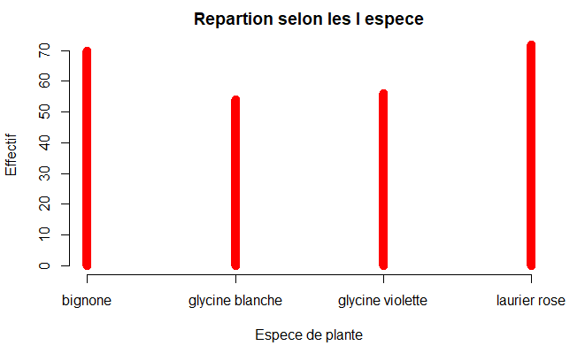

```r
plot(table(mes_especes),lwd = 10,col="red",xlab = "Espece de plante",ylab = "Effectif",main="Repartion selon les l espece")
```

Exo3 Le DataSet Mesures5 complète le DataSet Mesures en ajoutant de nouvelles variables, notamment une variable discrète graines qui compte le nombre de raines dans certains fruits (qui en possèdent).

```r
Mesures5
```

| masse | taille | graines | masse_sec | espece |
| --- | --- | --- | --- | --- |
| 28.6 | 19.1 | 4 | 9.3 | glycine blanche |
| 20.6 | 14.8 | 3 | 7.7 | glycine blanche |
| 29.2 | 19.7 | 5 | 10.4 | glycine blanche |
| 32.0 | 21.1 | 7 | 11.5 | glycine blanche |
| 24.5 | 19.4 | 4 | 8.4 | glycine blanche |
| 29.0 | 19.5 | 4 | 10.3 | glycine blanche |
| 28.9 | 18.9 | 4 | 10.1 | glycine blanche |
| 18.2 | 14.6 | 2 | 6.3 | glycine blanche |
| 7.9 | 10.2 | 1 | 2.7 | glycine blanche |
| 15.5 | 14.6 | 2 | 5.5 | glycine blanche |

[output cut: 242 more lines]

```r
NA
```

1. Quelles sont les espèces pour lesquelles cette variable est renseignée (n’est pas NA qui signifie Not Available) ?

```r
which(is.na(Mesures5$graines))
```

```
  [1] 111 112 113 114 115 116 117 118 119 120 121 122 123 124 125 126 127 128 129 130 131 132 133 134 135 136 137 138 139 140 141 142 143 144 145 146 147 148
 [39] 149 150 151 152 153 154 155 156 157 158 159 160 161 162 163 164 165 166 167 168 169 170 171 172 173 174 175 176 177 178 179 180 181 182 183 184 185 186
 [77] 187 188 189 190 191 192 193 194 195 196 197 198 199 200 201 202 203 204 205 206 207 208 209 210 211 212 213 214 215 216 217 218 219 220 221 222 223 224
[115] 225 226 227 228 229 230 231 232 233 234 235 236 237 238 239 240 241 242 243 244 245 246 247 248 249 250 251 252
```

```r
Mesures5[which(is.na(Mesures5$graines)),]
```

|  | masse | taille | graines | masse_sec | espece |
| --- | --- | --- | --- | --- | --- |
| 111 | 10.9 | 12.8 | NA | 3.0 | bignone |
| 112 | 6.6 | 10.5 | NA | 1.1 | bignone |
| 113 | 22.5 | 18.0 | NA | 3.4 | bignone |
| 114 | 33.7 | 21.5 | NA | 6.6 | bignone |
| 115 | 20.6 | 17.8 | NA | 3.5 | bignone |
| 116 | 16.6 | 16.3 | NA | 4.3 | bignone |
| 117 | 14.2 | 17.4 | NA | 2.1 | bignone |
| 118 | 13.8 | 15.7 | NA | 2.1 | bignone |
| 119 | 14.0 | 17.3 | NA | 2.4 | bignone |
| 120 | 8.7 | 13.4 | NA | 2.2 | bignone |

[output cut: 132 more lines]

```r
NA
```

2. Utiliser la commande na.exclude pour récupérer les valeurs disponibles de la varaible graines.

```r
mes_gaines<-na.exclude(Mesures5$graines)
length(mes_gaines)
```

```
[1] 110
```

3. Quelle sont les modalités de cette variable ? Qulle est la moyenne ? La médiane ? Le mode ? L’écart-type ?

```r
table(mes_gaines)
```

```
mes_gaines
 1  2  3  4  5  6  7
11 41 27 16 10  2  3
```

```r
summary(mes_gaines)
```

```
   Min. 1st Qu.  Median    Mean 3rd Qu.    Max.
  1.000   2.000   3.000   2.918   4.000   7.000
```

```r
mean(mes_gaines)
```

```
[1] 2.918182
```

```r
median(mes_gaines)
```

```
[1] 3
```

```r
sd(mes_gaines)
```

```
[1] 1.375619
```

```r
IQR(mes_gaines)
```

```
[1] 2
```

4. Donner le tableau des effectifs et le tableau des fréquences tableau freaquence

```r
prop.table(table(mes_gaines))
```

```
mes_gaines
         1          2          3          4          5          6          7
0.10000000 0.37272727 0.24545455 0.14545455 0.09090909 0.01818182 0.02727273
```

5. Donner le tableau des efefctifs cumulés croissants

```r
cumsum(table(mes_gaines))
```

```
  1   2   3   4   5   6   7
 11  52  79  95 105 107 110
```

6. Décrire cette variable graphiquement :

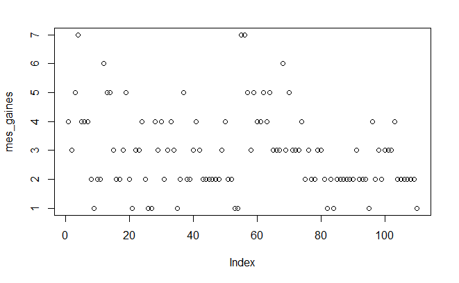

```r
plot(mes_gaines)
```

1. par un diagramme en bâtons

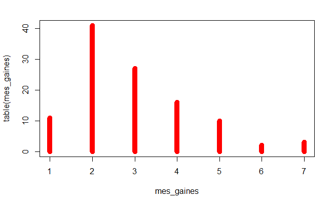

```r
plot(table(mes_gaines),lwd = "10",col="red")
```

2. par un diagramme par secteurs circulaires

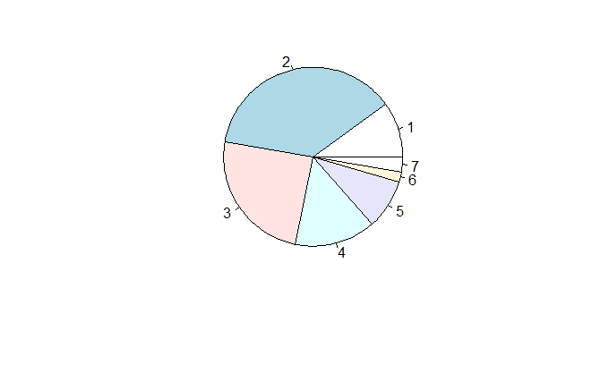

```r
pie(table(mes_gaines))
```

3. par la courbe des efefctifs cumulés croissants

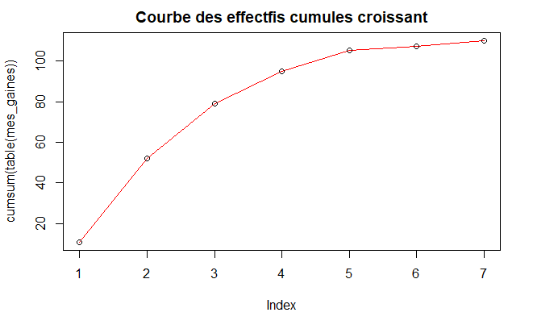

```r
plot(cumsum(table(mes_gaines)),type = "l",col="red",main = "Courbe des effectfis cumules croissant")
points(cumsum((table(mes_gaines))))
```

```r
skewness(mes_gaines)
```

```
Error in skewness(mes_gaines) : could not find function "skewness"
```

Exo4:

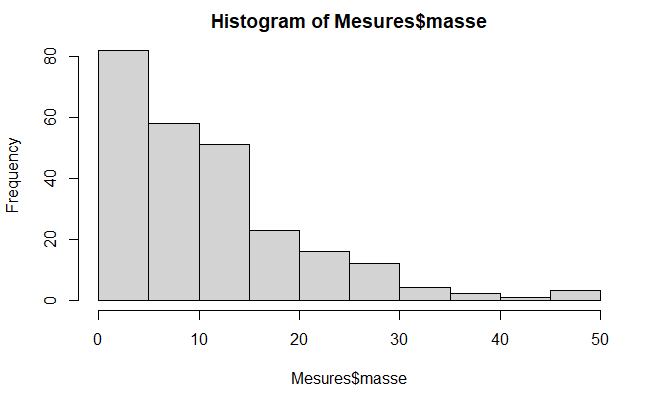

```r
mon_histo <- hist(Mesures$masse)
```

```r
str(mon_histo)
```

```
List of 6
 $ breaks  : num [1:11] 0 5 10 15 20 25 30 35 40 45 ...
 $ counts  : int [1:10] 82 58 51 23 16 12 4 2 1 3
 $ density : num [1:10] 0.0651 0.046 0.0405 0.0183 0.0127 ...
 $ mids    : num [1:10] 2.5 7.5 12.5 17.5 22.5 27.5 32.5 37.5 42.5 47.5
 $ xname   : chr "Mesures$masse"
 $ equidist: logi TRUE
 - attr(*, "class")= chr "histogram"
```

1. Calculez la plus petite et la plus grande valeur de la variable masse et donnez son étendue ;

```r
mes_masses<-Mesures$masse
min(mes_masses)
```

```
[1] 1
```

```r
max(mes_masses)
```

```
[1] 49.2
```

```r
range(mes_masses)
```

```
[1]  1.0 49.2
```

```r
minmax<-range(mes_masses)
etendue<-minmax[2]-minmax[1]
etendue
```

```
[1] 48.2
```

2. Donnez sa moyenne, sa médiane, son écart-type et son intervalle interquartile ;

```r
summary(mes_masses)
```

```
   Min. 1st Qu.  Median    Mean 3rd Qu.    Max.
   1.00    4.50    8.40   11.13   14.60   49.20
```

```r
sd(mes_masses)
```

```
[1] 9.001561
```

```r
IQR(mes_masses)
```

```
[1] 10.1
```

3. Dans le regroupement par classe,
1. Quelle est la classe modale ?

```r
max(mon_histo$counts)
```

```
[1] 82
```

```r
e<-which(mon_histo$counts==82)
classe_modale<-c(mon_histo$breaks[e],mon_histo$breaks[e+1])
classe_modale
```

```
[1] 0 5
```

2. calculez les fréquences fi de chaque classe et vérifiez que la somme donne 1 et que les valeurs de mon_hist$density sont correctes.

```r
prop.table(mon_histo$counts)
```

```
 [1] 0.325396825 0.230158730 0.202380952 0.091269841 0.063492063 0.047619048 0.015873016 0.007936508 0.003968254 0.011904762
```

```r
sum(prop.table(mon_histo$counts)
)
```

```
[1] 1
```

```r
mon_histo$density*5 #multiple de l amplitudes des class(longeur)
```

```
 [1] 0.325396825 0.230158730 0.202380952 0.091269841 0.063492063 0.047619048 0.015873016 0.007936508 0.003968254 0.011904762
```

3. Calculer les effectifs cumulés et les fréquences cumulées croissantes.

```r
cumsum(mon_histo$counts)
```

```
 [1]  82 140 191 214 230 242 246 248 249 252
```

```r
cumsum(prop.table((mon_histo$counts)))
```

```
 [1] 0.3253968 0.5555556 0.7579365 0.8492063 0.9126984 0.9603175 0.9761905 0.9841270 0.9880952 1.0000000
```

4. Quelle est la valeur de la moyenne si on utilise une répartition statistique groupée ? Comparez avec la moyenne sur les données exactes.

```r
sum(mon_histo$mids * mon_histo$counts)/sum(mon_histo$counts)
```

[output not shown]

4. Si on utilise pour le regroupe en classes le découpage de [0, 50] en 5 intervalles de même taille, quelle est l’effectif de la classe modale ?
5. Décrire cette variable graphiquement :
1. avec un histogramme sur lequel on trave la courbe des densités
2. avec une courbe des effectifs cumulés croissants
3. avec un box-plot (boîte à moustache).
6. Calculer le coefficient d’asymétrie et d’aplatissement de la variable masse et interpréter ces résultats.

```r
p=0.4418605
n=2
k=0


res=ncol(combn(n,k))*p^k*(1-p)^(n-k)
res
```

```
[1] 0.3115197
```

```r
p=0.19/(0.19+0.24)
p
```

```
[1] 0.4418605
```

```r
res=0.4436766*0.3115197
res
```

```
[1] 0.138214
```